# Tugas 1

[figure not shown]

# PREDIKSI HARGA RUMAH UNTUK MENINGKATKAN TRASNPARANSI DALAM TRANSAKSI JUAL BELI DI TEBET JAKARTA SELATAN

# Pendahuluan

## Latar belakang

Transaksi jual beli properti, khususnya di kawasan perkotaan seperti Tebet, Jakarta Selatan, seringkali diwarnai oleh ketidakjelasan informasi mengenai harga pasar. Faktor-faktor seperti luas bangunan, luas tanah, jumlah kamar, jumlah kamar mandi, dan fasilitas tambahan (seperti garasi) dapat memengaruhi harga suatu properti. Namun, kurangnya transparansi dalam penentuan harga sering kali menimbulkan kebingungan bagi pembeli maupun penjual.

Penelitian ini bertujuan untuk membangun model prediksi harga properti di kawasan Tebet, Jakarta Selatan. Dengan menganalisis data dari berbagai parameter, model ini diharapkan mampu memberikan gambaran harga pasar yang realistis dan meningkatkan transparansi dalam transaksi jual beli properti. Pendekatan ini diharapkan dapat meminimalkan kesenjangan informasi antara penjual dan pembeli, serta mendorong efisiensi di pasar properti.

## Tujuan

Pengembangan alat bantu prediksi harga properti berbasis metode regresi linear merupakan langkah inovatif untuk meningkatkan efisiensi dan keadilan dalam transaksi jual beli properti di kawasan Tebet, Jakarta Selatan. Alat ini dirancang untuk menghasilkan estimasi harga properti yang akurat dengan memanfaatkan data historis serta karakteristik properti, seperti luas bangunan, luas tanah, jumlah kamar tidur, kamar mandi, dan fasilitas tambahan lainnya.

Melalui pendekatan berbasis data, alat bantu ini diharapkan mampu memberikan estimasi harga yang objektif dan transparan. Hal ini tidak hanya membantu pembeli dalam memahami harga pasar yang wajar, tetapi juga memberikan panduan kepada penjual untuk menentukan harga jual yang kompetitif. Selain itu, agen properti juga dapat memanfaatkan alat ini sebagai referensi dalam negosiasi dan penawaran.

Dengan teknologi prediksi yang mudah diakses, alat bantu ini dirancang untuk mengurangi ketidakpastian dan kesenjangan informasi antara pihak-pihak yang terlibat dalam transaksi properti. Transparansi yang dihasilkan dari penggunaan alat ini diyakini akan mendorong kepercayaan antara pembeli dan penjual, serta meningkatkan efisiensi pasar properti secara keseluruhan.

## Rumusan Masalah

# Data Understanding

Dataset yang saya gunakan diambil dari website kaggle, berikut link dataset nya https://www.kaggle.com/datasets/wisnuanggara/daftar-harga-rumah, Dataset ini memiliki 7 fitur yaitu:

1. NAMA RUMAH : title rumah.
2. HARGA : harga dari rumah.
3. LB : jumlah luas bangunan.
4. LT : jumlah luas tanah.
5. KT : jumlah kamar tidur.
6. KM : jumlah kamar mandi.
7. GRS : jumlah kapasitas mobil dalam garasi.

Dataset ini memiliki 1010 baris data

Import library yang dibutuhkan

```python
import numpy as np
    import pandas as pd
    import matplotlib.pyplot as plt
    import seaborn as sns
    from sklearn.model_selection import train_test_split, GridSearchCV
    from sklearn.linear_model import Ridge
    from sklearn.pipeline import make_pipeline
    from sklearn.linear_model import LinearRegression
    from sklearn.preprocessing import StandardScaler
    from sklearn.metrics import mean_absolute_error, mean_squared_error, r2_score
    import warnings
    warnings.filterwarnings('ignore')
```

```python
from google.colab import drive
    drive.mount('/content/drive')
```

## Menampilkan Data

```python
df = pd.read_excel('/content/drive/MyDrive/PSD/DATA RUMAH.xlsx')
    df.head()
```

|  | NO | NAMA RUMAH | HARGA | LB | LT | KT | KM | GRS |
| --- | --- | --- | --- | --- | --- | --- | --- | --- |
| 0 | 1 | Rumah Murah Hook Tebet Timur, Tebet, Jakarta S... | 3800000000 | 220 | 220 | 3 | 3 | 0 |
| 1 | 2 | Rumah Modern di Tebet dekat Stasiun, Tebet, Ja... | 4600000000 | 180 | 137 | 4 | 3 | 2 |
| 2 | 3 | Rumah Mewah 2 Lantai Hanya 3 Menit Ke Tebet, T... | 3000000000 | 267 | 250 | 4 | 4 | 4 |
| 3 | 4 | Rumah Baru Tebet, Tebet, Jakarta Selatan | 430000000 | 40 | 25 | 2 | 2 | 0 |
| 4 | 5 | Rumah Bagus Tebet komp Gudang Peluru lt 350m, ... | 9000000000 | 400 | 355 | 6 | 5 | 3 |

## Menentukan Missing Value

```python
df = pd.read_excel('/content/drive/MyDrive/PSD/DATA RUMAH.xlsx')
      df.isnull().sum()
```

|  | 0 |
| --- | --- |
| NO | 0 |
| NAMA RUMAH | 0 |
| HARGA | 0 |
| LB | 0 |
| LT | 0 |
| KT | 0 |
| KM | 0 |
| GRS | 0 |

**dtype:** int64

**Kesimpulan**: Dapat dilihat bahwa tidak terdapat missing values dalam dataset sehingga tidak dibutuhkan proses lebih lanjut untuk penanganan missing value.

```python
df.info()
    print("Shape of data:")
    print(df.shape)
```

```
<class 'pandas.core.frame.DataFrame'>
    RangeIndex: 1010 entries, 0 to 1009
    Data columns (total 8 columns):
     #   Column      Non-Null Count  Dtype
    ---  ------      --------------  -----
     0   NO          1010 non-null   int64
     1   NAMA RUMAH  1010 non-null   object
     2   HARGA       1010 non-null   int64
     3   LB          1010 non-null   int64
     4   LT          1010 non-null   int64
     5   KT          1010 non-null   int64
     6   KM          1010 non-null   int64
     7   GRS         1010 non-null   int64
    dtypes: int64(7), object(1)
    memory usage: 63.2+ KB
    Shape of data:
    (1010, 8)
```

```python
print("Jumlah data duplicated:", df.duplicated().sum(), end="")
    df.isna().sum()
```

```
Jumlah data duplicated: 0
```

|  | 0 |
| --- | --- |
| NO | 0 |
| NAMA RUMAH | 0 |
| HARGA | 0 |
| LB | 0 |
| LT | 0 |
| KT | 0 |
| KM | 0 |
| GRS | 0 |

**dtype:** int64

```python
df = df.rename(columns={
        'NO': 'nomor',
        'NAMA RUMAH': 'nama_rumah',
        'HARGA': 'harga',
        'LB': 'lb',
        'LT': 'lt',
        'KT': 'kt',
        'KM': 'km',
        'GRS': 'grs'
    })
    df
```

|  | nomor | nama_rumah | harga | lb | lt | kt | km | grs |
| --- | --- | --- | --- | --- | --- | --- | --- | --- |
| 0 | 1 | Rumah Murah Hook Tebet Timur, Tebet, Jakarta S... | 3800000000 | 220 | 220 | 3 | 3 | 0 |
| 1 | 2 | Rumah Modern di Tebet dekat Stasiun, Tebet, Ja... | 4600000000 | 180 | 137 | 4 | 3 | 2 |
| 2 | 3 | Rumah Mewah 2 Lantai Hanya 3 Menit Ke Tebet, T... | 3000000000 | 267 | 250 | 4 | 4 | 4 |
| 3 | 4 | Rumah Baru Tebet, Tebet, Jakarta Selatan | 430000000 | 40 | 25 | 2 | 2 | 0 |
| 4 | 5 | Rumah Bagus Tebet komp Gudang Peluru lt 350m, ... | 9000000000 | 400 | 355 | 6 | 5 | 3 |
| ... | ... | ... | ... | ... | ... | ... | ... | ... |
| 1005 | 1006 | Rumah Strategis Akses Jalan 2mobil Di Menteng ... | 9000000000 | 450 | 550 | 10 | 10 | 3 |
| 1006 | 1007 | Tebet Rumah Siap Huni Jln 2 Mbl Nyaman | 4000000000 | 160 | 140 | 4 | 3 | 2 |
| 1007 | 1008 | Di Kebun Baru Rumah Terawat, Area Strategis | 4000000000 | 139 | 230 | 4 | 4 | 1 |
| 1008 | 1009 | Dijual Cepat Rumah Komp Depkeu Dr Soepomo Tebe... | 19000000000 | 360 | 606 | 7 | 4 | 0 |
| 1009 | 1010 | Dijual Rumah Kokoh Di Gudang Peluru | 10500000000 | 420 | 430 | 7 | 4 | 2 |

1010 rows × 8 columns

```python
#Mengganti satuan harga agar lebih readable
    df['harga'] = (df['harga']/10).astype(int)
    df.drop(columns=['nomor'], inplace=True)
    df.head()
```

|  | nama_rumah | harga | lb | lt | kt | km | grs |
| --- | --- | --- | --- | --- | --- | --- | --- |
| 0 | Rumah Murah Hook Tebet Timur, Tebet, Jakarta S... | 380000000 | 220 | 220 | 3 | 3 | 0 |
| 1 | Rumah Modern di Tebet dekat Stasiun, Tebet, Ja... | 460000000 | 180 | 137 | 4 | 3 | 2 |
| 2 | Rumah Mewah 2 Lantai Hanya 3 Menit Ke Tebet, T... | 300000000 | 267 | 250 | 4 | 4 | 4 |
| 3 | Rumah Baru Tebet, Tebet, Jakarta Selatan | 43000000 | 40 | 25 | 2 | 2 | 0 |
| 4 | Rumah Bagus Tebet komp Gudang Peluru lt 350m, ... | 900000000 | 400 | 355 | 6 | 5 | 3 |

```python
q1 = df['harga'].quantile(0.25)
    median = df['harga'].median()
    q3 = df['harga'].quantile(0.75)

    def classification_harga(harga):
        if harga <= q1:
            return 'Murah'
        elif harga <= median:
            return 'Menengah'
        else:
            return 'Mahal'

    # Menambahkan kolom baru 'Klasifikasi Harga'
    df['tingkat_harga'] = df['harga'].apply(classification_harga)

    # Menampilkan DataFrame dengan kolom baru
    df.head()
```

|  | nama_rumah | harga | lb | lt | kt | km | grs | tingkat_harga |
| --- | --- | --- | --- | --- | --- | --- | --- | --- |
| 0 | Rumah Murah Hook Tebet Timur, Tebet, Jakarta S... | 380000000 | 220 | 220 | 3 | 3 | 0 | Menengah |
| 1 | Rumah Modern di Tebet dekat Stasiun, Tebet, Ja... | 460000000 | 180 | 137 | 4 | 3 | 2 | Menengah |
| 2 | Rumah Mewah 2 Lantai Hanya 3 Menit Ke Tebet, T... | 300000000 | 267 | 250 | 4 | 4 | 4 | Murah |
| 3 | Rumah Baru Tebet, Tebet, Jakarta Selatan | 43000000 | 40 | 25 | 2 | 2 | 0 | Murah |
| 4 | Rumah Bagus Tebet komp Gudang Peluru lt 350m, ... | 900000000 | 400 | 355 | 6 | 5 | 3 | Mahal |

```python
df.describe()
```

|  | harga | lb | lt | kt | km | grs |
| --- | --- | --- | --- | --- | --- | --- |
| count | 1.010000e+03 | 1010.000000 | 1010.000000 | 1010.000000 | 1010.000000 | 1010.000000 |
| mean | 7.628987e+08 | 276.539604 | 237.432673 | 4.668317 | 3.607921 | 1.920792 |
| std | 7.340946e+08 | 177.864557 | 179.957604 | 1.572776 | 1.420066 | 1.510998 |
| min | 4.300000e+07 | 40.000000 | 25.000000 | 2.000000 | 1.000000 | 0.000000 |
| 25% | 3.262500e+08 | 150.000000 | 130.000000 | 4.000000 | 3.000000 | 1.000000 |
| 50% | 5.000000e+08 | 216.500000 | 165.000000 | 4.000000 | 3.000000 | 2.000000 |
| 75% | 9.000000e+08 | 350.000000 | 290.000000 | 5.000000 | 4.000000 | 2.000000 |
| max | 6.500000e+09 | 1126.000000 | 1400.000000 | 10.000000 | 10.000000 | 10.000000 |

Selain itu, semua kolom atau data yang digunakan, kecuali kolom nama_rumah, memiliki korelasi yang positf dengan harga.

## Explorasi Data

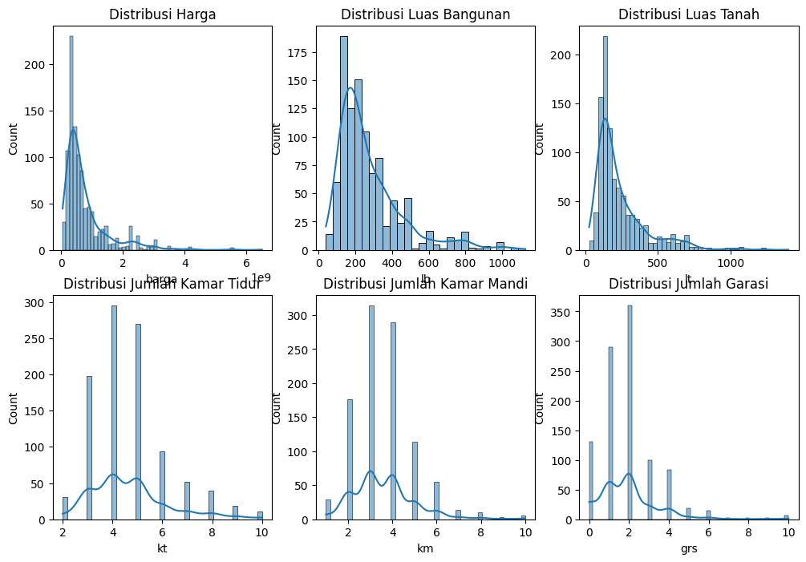

```python
plt.figure(figsize=(12, 8))
    plt.subplot(2, 3, 1)
    sns.histplot(df['harga'], kde=True)
    plt.title('Distribusi Harga')

    plt.subplot(2, 3, 2)
    sns.histplot(df['lb'], kde=True)
    plt.title('Distribusi Luas Bangunan')

    plt.subplot(2, 3, 3)
    sns.histplot(df['lt'], kde=True)
    plt.title('Distribusi Luas Tanah')

    plt.subplot(2, 3, 4)
    sns.histplot(df['kt'], kde=True)
    plt.title('Distribusi Jumlah Kamar Tidur')

    plt.subplot(2, 3, 5)
    sns.histplot(df['km'], kde=True)
    plt.title('Distribusi Jumlah Kamar Mandi')

    plt.subplot(2, 3, 6)
    sns.histplot(df['grs'], kde=True)
    plt.title('Distribusi Jumlah Garasi')
    plt.show()
```

Berdasarkan grafik distribusi diatas dapat kita tarik kesimpulan sebagai berikut:

1. Distribusi Harga,Harga memiliki distribusi skewed ke kanan, menunjukkan mayoritas properti memiliki harga yang rendah, sementara hanya sedikit properti yang memiliki harga sangat tinggi.
2. Distribusi Luas Bangunan, Distribusi Luas bangunan juga skewed ke kanan, artinya sebagian besar properti memiliki luas bangunan kecil hingga sedang.Properti dengan luas bangunan besar relatif lebih sedikit.
3. Distribusi Luas Tanah, mayoritas properti memiliki luas tanah yang kecil hingga sedang.Properti dengan luas tanah sangat besar lebih jarang ditemukan.
4. Distribusi Jumlah Kamar Tidur, Mayoritas properti memiliki jumlah kamar tidur antara 3 hingga 5 kamar, dengan puncaknya di sekitar 4 kamar.Ada beberapa properti dengan jumlah kamar yang jauh lebih banyak (hingga 10), tetapi ini sangat jarang.
5. Distribusi Jumlah Kamar Mandi, Properti dengan 2 hingga 4 kamar mandi mendominasi, dengan puncaknya di sekitar 3 kamar mandi.
6. Distribusi Jumlah Garasi, Sebagian besar properti memiliki 1 hingga 3 garasi, dengan puncak distribusi di 2 garasi.

Kesimpulan umum: Mayoritas variabel menunjukkan distribusi yang skewed ke kanan,Sebagian besar properti memiliki karakteristik yang umum, seperti harga yang relatif rendah, ukuran bangunan dan tanah kecil hingga sedang, serta jumlah kamar tidur, kamar mandi, dan garasi yang sedang.

## Menentukan Outlier

```python
# Memilih kolom numerik
    kolom_numerik = ['harga', 'lb', 'lt', 'kt', 'km', 'grs']

    # Inisialisasi dataframe untuk menyimpan outlier
    outlier_dict = {}

    # Perhitungan IQR untuk setiap kolom numerik
    for kolom in kolom_numerik:
        Q1 = df[kolom].quantile(0.25)  # Kuartil pertama (25%)
        Q3 = df[kolom].quantile(0.75)  # Kuartil ketiga (75%)
        IQR = Q3 - Q1  # Rentang antar-kuartil

        # Rentang normal
        batas_bawah = Q1 - 1.5 * IQR
        batas_atas = Q3 + 1.5 * IQR

        # Identifikasi outlier
        outliers = df[(df[kolom] < batas_bawah) | (df[kolom] > batas_atas)]

        # Menyimpan informasi outlier
        outlier_dict[kolom] = outliers

        print(f"Kolom: {kolom}")
        print(f"Batas bawah: {batas_bawah}, Batas atas: {batas_atas}")
        print(f"Jumlah outlier: {len(outliers)}\n")
```

```
Kolom: harga
    Batas bawah: -534375000.0, Batas atas: 1760625000.0
    Jumlah outlier: 94

    Kolom: lb
    Batas bawah: -150.0, Batas atas: 650.0
    Jumlah outlier: 53

    Kolom: lt
    Batas bawah: -110.0, Batas atas: 530.0
    Jumlah outlier: 88

    Kolom: kt
    Batas bawah: 2.5, Batas atas: 6.5
    Jumlah outlier: 153

    Kolom: km
    Batas bawah: 1.5, Batas atas: 5.5
    Jumlah outlier: 117

    Kolom: grs
    Batas bawah: -0.5, Batas atas: 3.5
    Jumlah outlier: 129
```

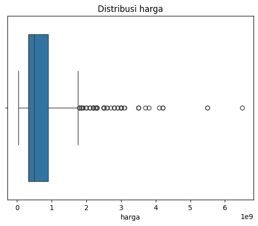

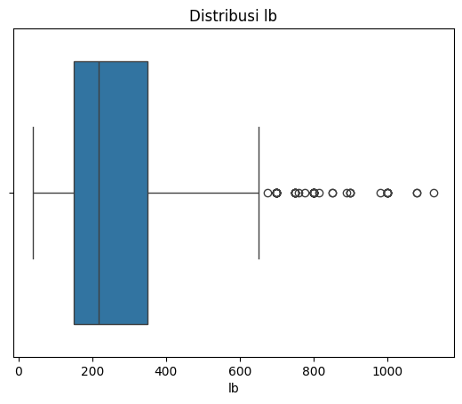

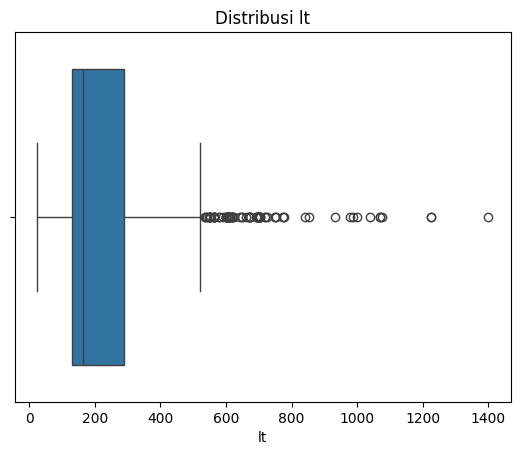

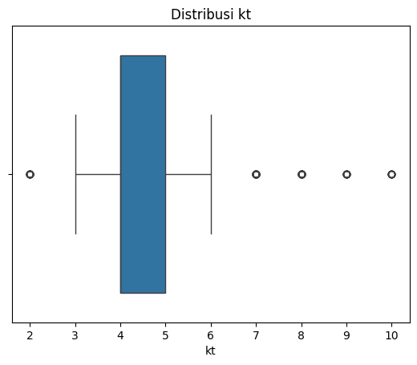

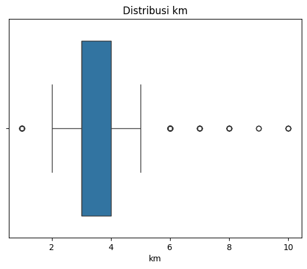

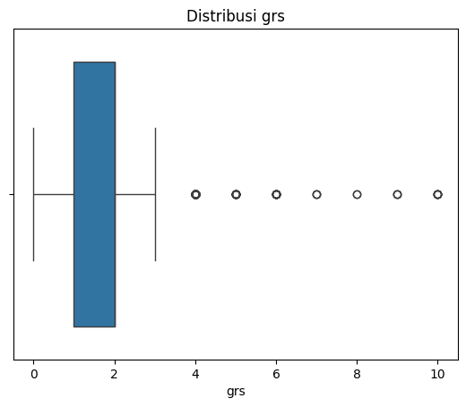

```python
import seaborn as sns
    import matplotlib.pyplot as plt

    for kolom in kolom_numerik:
        sns.boxplot(x=df[kolom])
        plt.title(f"Distribusi {kolom}")
        plt.show()
```

# Prepocessing

## Menghapus Outlier

```python
for kolom in ['harga', 'lb', 'lt', 'kt', 'km', 'grs']:
        Q1 = df[kolom].quantile(0.25)
        Q3 = df[kolom].quantile(0.75)
        IQR = Q3 - Q1
        batas_bawah = Q1 - 1.5 * IQR
        batas_atas = Q3 + 1.5 * IQR
        df = df[(df[kolom] >= batas_bawah) & (df[kolom] <= batas_atas)]
```

```python
# Mencari data yang masih menjadi outlier
        outliers = df[(df[kolom] < batas_bawah) | (df[kolom] > batas_atas)]
        print(f"Kolom: {kolom}")
        print(f"Jumlah outlier setelah penghapusan: {len(outliers)}")
        print()
```

```
Kolom: grs
    Jumlah outlier setelah penghapusan: 0
```

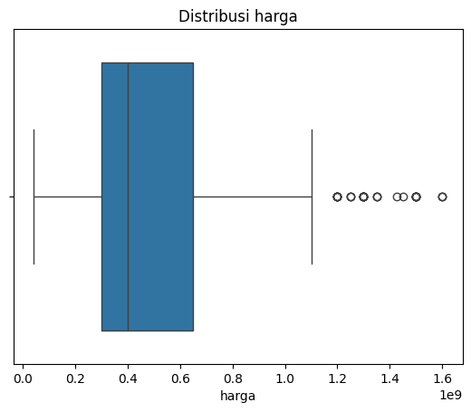

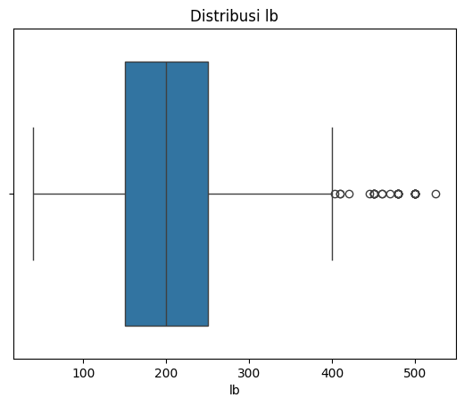

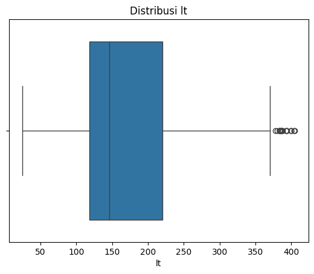

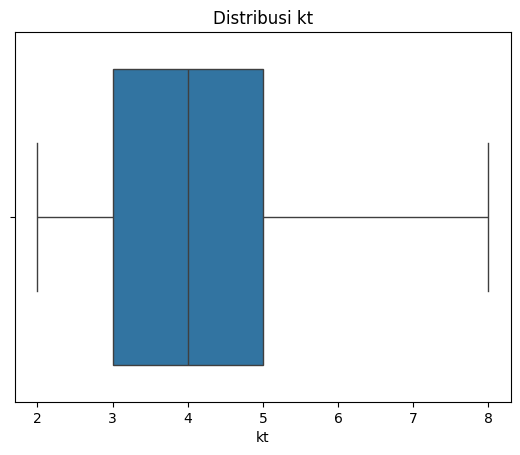

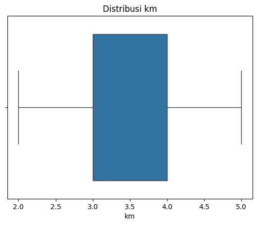

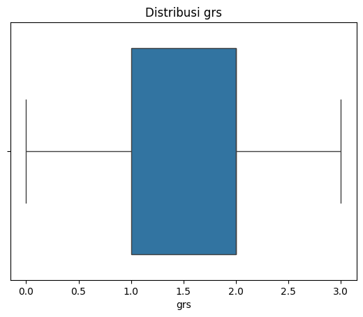

```python
import seaborn as sns
    import matplotlib.pyplot as plt

    for kolom in kolom_numerik:
        sns.boxplot(x=df[kolom])
        plt.title(f"Distribusi {kolom}")
        plt.show()
```

## Visualisasi Matriks Korelasi

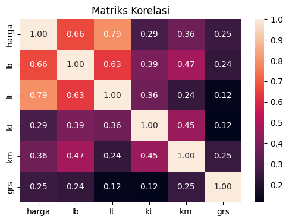

```python
# Menghapus kolom 'tingkat_harga' dan 'daerah'
    df_corr = df.drop(['tingkat_harga','nama_rumah'], axis=1)

    # Menghitung matriks korelasi
    correlation_all = df_corr.corr()

    # Menampilkan matriks korelasi
    plt.figure(figsize=(6, 4))
    sns.heatmap(correlation_all, annot=True, cmap='rocket', fmt=".2f")
    plt.title('Matriks Korelasi')
    plt.show()
```

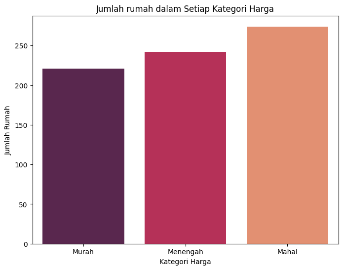

| tingkat_harga | count |
| --- | --- |
| Mahal | 274 |
| Menengah | 242 |
| Murah | 221 |

**dtype:** int64

```python
plt.figure(figsize=(8, 6))
    sns.countplot(data=df, x='tingkat_harga', order=['Murah', 'Menengah', 'Mahal'], palette='rocket')
    plt.title('Jumlah rumah dalam Setiap Kategori Harga')
    plt.xlabel('Kategori Harga')
    plt.ylabel('Jumlah Rumah')
    plt.show()

    df['tingkat_harga'].value_counts()
```

# Pemodelan Regresi Linear

```python
from sklearn.linear_model import LinearRegression
    from sklearn.model_selection import train_test_split
    from sklearn.metrics import mean_absolute_error, mean_squared_error, r2_score

    # Memisahkan fitur dan target
    X = df[['lb', 'lt', 'kt', 'km', 'grs']].values  # Fitur
    y = df['harga'].values  # Target

    # Membagi dataset menjadi data latih 80% dan data uji 20%
    X_train, X_test, y_train, y_test = train_test_split(X, y, test_size=0.2, random_state=42)

    # Membuat model Linear Regression
    model = LinearRegression()

    # Melatih model
    model.fit(X_train, y_train)

    # Melakukan prediksi pada data uji
    y_pred = model.predict(X_test)

    print(model.coef_)
    print(model.intercept_)
```

```
[   582102.93371314   2528957.3465763  -25726399.67659594
      43550386.28063191  32410286.79744639]
    -127315306.02443987
```

# Evaluasi

```python
# Menghitung metrik evaluasi
    mse = mean_squared_error(y_test, y_pred)
    mape = np.mean(np.abs((y_test - y_pred) / y_test)) * 100  # MAPE dalam persen
    r2 = r2_score(y_test, y_pred)

    # Menampilkan metrik evaluasi
    print("Hasil Evaluasi Model:")
    print(f'MSE (Mean Squared Error): {mse:.2f}')
    print(f'MAPE (Mean Absolute Percentage Error): {mape:.2f}%')
    print(f'R2 Score (R-squared): {r2:.2f}')
```

```
Hasil Evaluasi Model:
    MSE (Mean Squared Error): 27998466436340576.00
    MAPE (Mean Absolute Percentage Error): 32.20%
    R2 Score (R-squared): 0.64
```

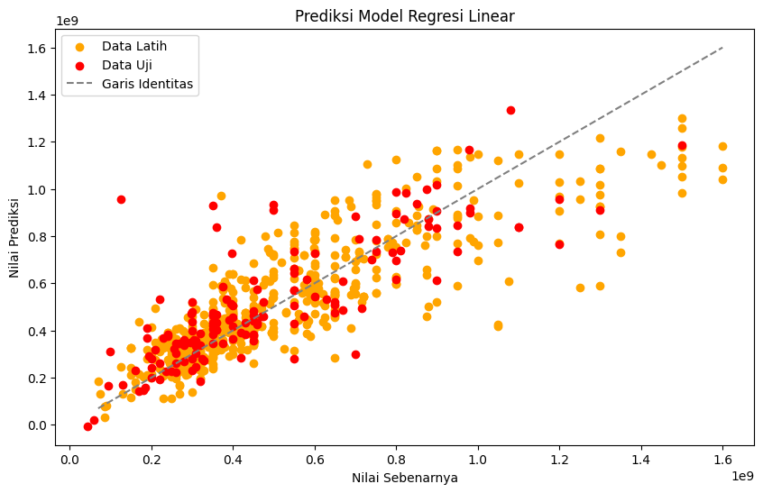

```python
import matplotlib.pyplot as plt

    # Visualisasi regresi untuk data latih dan data uji
    plt.figure(figsize=(10, 6))

    # Plot data latih
    plt.scatter(y_train, y_train_pred, color='orange', label='Data Latih')

    # Plot data uji
    plt.scatter(y_test, y_pred, color='red', label='Data Uji')

    # Plot garis identitas
    plt.plot([min(y_train), max(y_train)], [min(y_train), max(y_train)], linestyle='--', color='gray', label='Garis Identitas')

    # Label sumbu x dan y
    plt.xlabel('Nilai Sebenarnya')
    plt.ylabel('Nilai Prediksi')

    # Judul plot
    plt.title('Prediksi Model Regresi Linear')

    # Menambahkan legenda
    plt.legend()

    # Menampilkan plot
    plt.show()
```

# Prediksi

```python
# Definisikan fungsi untuk memprediksi harga berdasarkan fitur yang dimasukkan
    def predict_house_price(lb, lt, kt, km, grs):
        # Lakukan prediksi harga menggunakan model regresi linier
        predicted_price = model.predict([[lb, lt, kt, km, grs]])

        # Tampilkan hasil prediksi
        print("Harga rumah impian anda diperkirakan sekitar IDR {:,.3f} juta".format(predicted_price[0]))

    # Input dari pengguna
    lb = float(input("Masukkan luas bangunan (LB) dalam m2: "))
    lt = float(input("Masukkan luas tanah (LT) dalam m2: "))
    kt = int(input("Masukkan jumlah kamar tidur (KT): "))
    km = int(input("Masukkan jumlah kamar mandi (KM): "))
    grs = int(input("Masukkan jumlah garasi (GRS): "))

    # Panggil fungsi prediksi
    predict_house_price(lb, lt, kt, km, grs)
```

```
Masukkan luas bangunan (LB) dalam m2: 220
    Masukkan luas tanah (LT) dalam m2: 220
    Masukkan jumlah kamar tidur (KT): 3
    Masukkan jumlah kamar mandi (KM): 3
    Masukkan jumlah garasi (GRS): 0
    Harga rumah impian anda diperkirakan sekitar IDR 610,589,915.451 juta
```